# mixed_effects_basics

Soumya Banerjee

6 January 2019

# R Markdown for a mixed effects model

This is an R Markdown document for a mixed effects tutorial. This is adapted from the following sources

http://www.bodowinter.com./tutorial/bw_LME_tutorial2.pdf

http://www.bodowinter.com./tutorial/bw_LME_tutorial1.pdf

# Loading data and libraries

# Plots to visualize data

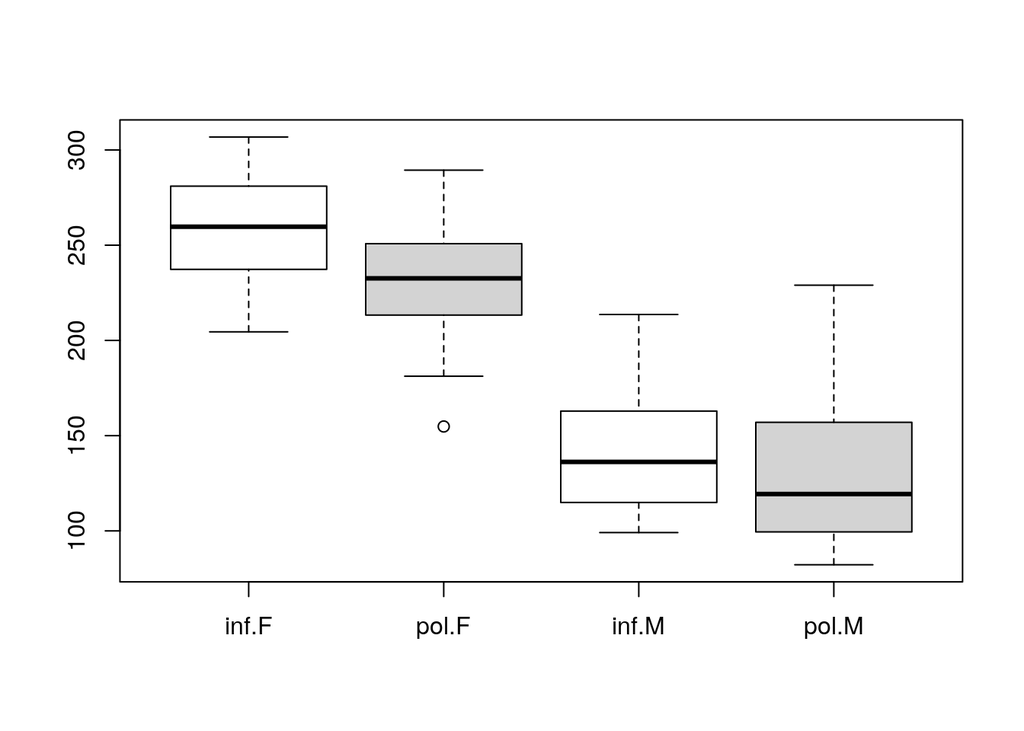

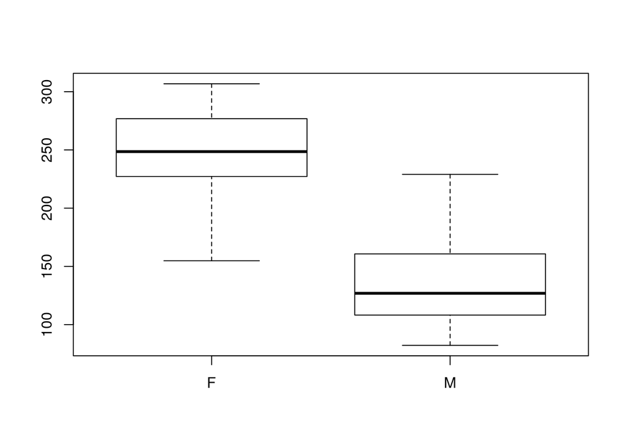

# Make a simple linear mixed effects model

```
## Linear mixed model fit by REML ['lmerMod']
## Formula: frequency ~ attitude + (1 | subject) + (1 | scenario)
##    Data: df_politeness
##
## REML criterion at convergence: 793.5
##
## Scaled residuals:
##     Min      1Q  Median      3Q     Max
## -2.2006 -0.5817 -0.0639  0.5625  3.4385
##
## Random effects:
##  Groups   Name        Variance Std.Dev.
##  scenario (Intercept)  219     14.80
##  subject  (Intercept) 4015     63.36
##  Residual              646     25.42
## Number of obs: 83, groups:  scenario, 7; subject, 6
##
## Fixed effects:
##             Estimate Std. Error t value
## (Intercept)  202.588     26.754   7.572
## attitudepol  -19.695      5.585  -3.527
##
## Correlation of Fixed Effects:
##             (Intr)
## attitudepol -0.103
```

The fixed effects output mirrors the coefficient table that we considered in tutorial 1 when we talked about the results of our linear model analysis. The coefficient “attitudepol” is the slope for the categorical effect of politeness. Minus 19.695 means that to go from “informal” to “polite”, you have to go down -19.695 Hz. In other words: pitch is lower in polite speech than in informal speech, by about 20 Hz. Then, there’s a standard error associated with this slope, and a tvalue, which is simply the estimate (20 Hz) divided by the standard error (check this by performing the calculation by hand).

Now, let’s consider the intercept. In tutorial 1, we already talked about the fact that oftentimes, model intercepts are not particularly meaningful. But this intercept is especially weird. It’s 202.588 Hz … where does that value come from? If you look back at the boxplot that we constructed earlier, you can see that the value 202.588 Hz seems to fall halfway between males and females (in the informal condition) – and this is indeed what this intercept represents. It’s the average of our data for the informal condition.

As we did not inform our model that there are two sexes in our dataset, the intercept is particularly off, in between the voice pitch of males and females. This is just like the classic example of a farm with a dozen hens and a dozen cows … where the mean legs of all farm animals considered together is three, not a particularly informative representation of what is going on at the farm.

# Adding gender as an additional fixed effect.

We now add “gender” as a fixed effect because the relationship between sex and pitch is systematic and predictable (i.e., we expect females to have higher pitch). This is different from the random effects subject and item, where the relationship between these and pitch is much more unpredictable and “random”. We’ll talk more about the distinction between fixed and random effects later.

```
## Linear mixed model fit by REML ['lmerMod']
## Formula: frequency ~ attitude + gender + (1 | subject) + (1 | scenario)
##    Data: df_politeness
##
## REML criterion at convergence: 775.5
##
## Scaled residuals:
##     Min      1Q  Median      3Q     Max
## -2.2591 -0.6236 -0.0772  0.5388  3.4795
##
## Random effects:
##  Groups   Name        Variance Std.Dev.
##  scenario (Intercept) 219.5    14.81
##  subject  (Intercept) 615.6    24.81
##  Residual             645.9    25.41
## Number of obs: 83, groups:  scenario, 7; subject, 6
##
## Fixed effects:
##             Estimate Std. Error t value
## (Intercept)  256.846     16.116  15.938
## attitudepol  -19.721      5.584  -3.532
## genderM     -108.516     21.013  -5.164
##
## Correlation of Fixed Effects:
##             (Intr) atttdp
## attitudepol -0.173
## genderM     -0.652  0.004
```

```
## Computing profile confidence intervals ...
```

```
##                   2.5 %    97.5 %
## .sig01         6.864422  29.99058
## .sig02        11.420516  42.73985
## .sigma        21.599106  30.05092
## (Intercept)  226.084997 287.60823
## attitudepol  -30.739625  -8.69669
## genderM     -149.340247 -67.68308
```

```
## Computing bootstrap confidence intervals ...
```

[output not shown]

```
##                   2.5 %     97.5 %
## .sig01         3.049296  24.764603
## .sig02         4.668220  43.595143
## .sigma        21.065636  29.092576
## (Intercept)  225.479235 288.320514
## attitudepol  -31.328723  -6.936065
## genderM     -150.047469 -68.208486
```

Note that compared to our earlier model without the fixed effect gender, the variation that’s associated with the random effect “subject” dropped considerably. This is because the variation that is due to gender was confounded with the variation that’s due to subject. The model did not know about males and females, and so its predictions were relatively more off, creating relatively larger residuals. Now that we have added the effect of gender, we have shifted a considerable amount of the variance that was previously in the random effects component (differences between male and female individuals) to the fixed effects component.

We see that males and females differ by about 109 Hz.

The intercept is now much higher (256.846 Hz), as it now represents the female category (for the informal condition). The coefficient for the effect of attitude didn’t change much.

```
## Simple model without gender
```

```
## Linear mixed model fit by REML ['lmerMod']
## Formula: frequency ~ attitude + (1 | subject) + (1 | scenario)
##    Data: df_politeness
##
## REML criterion at convergence: 793.5
##
## Scaled residuals:
##     Min      1Q  Median      3Q     Max
## -2.2006 -0.5817 -0.0639  0.5625  3.4385
##
## Random effects:
##  Groups   Name        Variance Std.Dev.
##  scenario (Intercept)  219     14.80
##  subject  (Intercept) 4015     63.36
##  Residual              646     25.42
## Number of obs: 83, groups:  scenario, 7; subject, 6
##
## Fixed effects:
##             Estimate Std. Error t value
## (Intercept)  202.588     26.754   7.572
## attitudepol  -19.695      5.585  -3.527
##
## Correlation of Fixed Effects:
##             (Intr)
## attitudepol -0.103
```

```
## Complex model with gender
```

```
## Linear mixed model fit by REML ['lmerMod']
## Formula: frequency ~ attitude + gender + (1 | subject) + (1 | scenario)
##    Data: df_politeness
##
## REML criterion at convergence: 775.5
##
## Scaled residuals:
##     Min      1Q  Median      3Q     Max
## -2.2591 -0.6236 -0.0772  0.5388  3.4795
##
## Random effects:
##  Groups   Name        Variance Std.Dev.
##  scenario (Intercept) 219.5    14.81
##  subject  (Intercept) 615.6    24.81
##  Residual             645.9    25.41
## Number of obs: 83, groups:  scenario, 7; subject, 6
##
## Fixed effects:
##             Estimate Std. Error t value
## (Intercept)  256.846     16.116  15.938
## attitudepol  -19.721      5.584  -3.532
## genderM     -108.516     21.013  -5.164
##
## Correlation of Fixed Effects:
##             (Intr) atttdp
## attitudepol -0.173
## genderM     -0.652  0.004
```

# Comparing two models

Here, I focus on the Likelihood Ratio Test as a means to attain p-values. Likelihood is the probability of seeing the data you collected given your model. The logic of the likelihood ratio test is to compare the likelihood of two models with each other. First, the model without the factor that you’re interested in (the null model), then the model with the factor that you’re interested in. Maybe an analogy helps you to wrap your head around this: Say, you’re a hiker, and you carry a bunch of different things with you (e.g., a gallon of water, a flashlight). To know whether each item affects your hiking speed, you need to get rid of it. So, you get rid of the flashlight and run without it. Your hiking speed is not affected much. Then, you get rid of the gallon of water, and you realize that your hiking speed is affected a lot. You would conclude that carrying a gallon of water with you significantly affects your hiking speed whereas carrying a flashlight does not. Expressed in formula, you would want to compare the following two “models” (think “hikes”) with each other: mdl1 = hiking speed ~ gallon of water + flashlight mdl2 = hiking speed ~ flashlight If there is a significant difference between “mdl2” and “mdl1”, then you know that the gallon of water matters.

Note one additional technical detail. I just added the argument REML=FALSE. Do not worry about it too much – but in case you’re interested, this changes some internal stuff (in particular, the likelihood estimator), and it is necessary to do this when you compare models using the likelihood ratio test (Pinheiro & Bates, 2000; Bolker et al., 2009).

```
## Linear mixed model fit by maximum likelihood  ['lmerMod']
## Formula: frequency ~ attitude + (1 | subject) + (1 | scenario)
##    Data: df_politeness
##
##      AIC      BIC   logLik deviance df.resid
##    817.0    829.1   -403.5    807.0       78
##
## Scaled residuals:
##     Min      1Q  Median      3Q     Max
## -2.2127 -0.5906 -0.0598  0.5675  3.4584
##
## Random effects:
##  Groups   Name        Variance Std.Dev.
##  scenario (Intercept)  216.8   14.72
##  subject  (Intercept) 3367.7   58.03
##  Residual              637.0   25.24
## Number of obs: 83, groups:  scenario, 7; subject, 6
##
## Fixed effects:
##             Estimate Std. Error t value
## (Intercept)  202.588     24.646   8.220
## attitudepol  -19.692      5.546  -3.551
##
## Correlation of Fixed Effects:
##             (Intr)
## attitudepol -0.111
```

```
## Linear mixed model fit by maximum likelihood  ['lmerMod']
## Formula: frequency ~ attitude + gender + (1 | subject) + (1 | scenario)
##    Data: df_politeness
##
##      AIC      BIC   logLik deviance df.resid
##    807.1    821.6   -397.6    795.1       77
##
## Scaled residuals:
##     Min      1Q  Median      3Q     Max
## -2.2958 -0.6456 -0.0776  0.5448  3.5121
##
## Random effects:
##  Groups   Name        Variance Std.Dev.
##  scenario (Intercept) 205.2    14.33
##  subject  (Intercept) 417.0    20.42
##  Residual             637.4    25.25
## Number of obs: 83, groups:  scenario, 7; subject, 6
##
## Fixed effects:
##             Estimate Std. Error t value
## (Intercept)  256.847     13.827  18.576
## attitudepol  -19.722      5.547  -3.555
## genderM     -108.517     17.572  -6.176
##
## Correlation of Fixed Effects:
##             (Intr) atttdp
## attitudepol -0.201
## genderM     -0.635  0.004
```

Now you have two models to compare with each other – one with the effect in question, one without the effect in question. We perform the likelihood ratio test using the anova() function:

```
## Data: df_politeness
## Models:
## m_model_simple_LRT: frequency ~ attitude + (1 | subject) + (1 | scenario)
## m_model_complex_LRT: frequency ~ attitude + gender + (1 | subject) + (1 | scenario)
##                     Df    AIC    BIC  logLik deviance  Chisq Chi Df
## m_model_simple_LRT   5 817.04 829.13 -403.52   807.04
## m_model_complex_LRT  6 807.10 821.61 -397.55   795.10 11.938      1
##                     Pr(>Chisq)
## m_model_simple_LRT
## m_model_complex_LRT    0.00055 ***
## ---
## Signif. codes:  0 '***' 0.001 '**' 0.01 '*' 0.05 '.' 0.1 ' ' 1
```

# Interaction effects

What happens if you have an interaction? We didn’t talk much about interactions yet, but say, you predicted “attitude” to have an effect on pitch that is somehow modulated through “gender”. For example, it could be that speaking politely versus informally has the opposite effect for men and women. Or it could be that women show a difference and men don’t (or vice versa). If you have such an inter-dependence between two factors (called an interaction), you can test it the following way:

Full model: frequency ~ attitude*gender Reduced model: frequency ~ attitude + gender

In R, interactions between two factors are specified with a “*” rather than a “+”.

```
## Linear mixed model fit by REML ['lmerMod']
## Formula: frequency ~ attitude + gender + attitude * gender + (1 | subject)
##    Data: df_politeness
##
## REML criterion at convergence: 778.2
##
## Scaled residuals:
##     Min      1Q  Median      3Q     Max
## -2.2334 -0.5105 -0.1551  0.4738  3.0875
##
## Random effects:
##  Groups   Name        Variance Std.Dev.
##  subject  (Intercept) 605.4    24.61
##  Residual             844.1    29.05
## Number of obs: 83, groups:  subject, 6
##
## Fixed effects:
##                     Estimate Std. Error t value
## (Intercept)          260.686     15.557  16.757
## attitudepol          -27.400      8.966  -3.056
## genderM             -116.195     22.000  -5.282
## attitudepol:genderM   16.190     12.763   1.269
##
## Correlation of Fixed Effects:
##             (Intr) atttdp gendrM
## attitudepol -0.288
## genderM     -0.707  0.204
## atttdpl:gnM  0.202 -0.703 -0.286
```

# Random slopes model

You see that each scenario and each subject is assigned a different intercept. That’s what we would expect, given that we have told the model with “(1|subject)” and “(1|scenario)” to take by-subject and by-item variability into account.

CONCEPT 1: intercept is the random noise part

But note also that the fixed effects (attitude and gender) are all the same for all subjects and items. Our model is what is called a random intercept model. In this model, we account for baseline-differences in pitch, but we assume that whatever the effect of politeness is, it’s going to be the same for all subjects and items.

CONCEPT 2: slope is the fixed effects part

```
## $scenario
##   (Intercept) attitudepol   genderM
## 1    243.3398   -19.72111 -108.5163
## 2    263.4292   -19.72111 -108.5163
## 3    268.2541   -19.72111 -108.5163
## 4    277.4757   -19.72111 -108.5163
## 5    254.9102   -19.72111 -108.5163
## 6    244.6724   -19.72111 -108.5163
## 7    245.8426   -19.72111 -108.5163
##
## $subject
##    (Intercept) attitudepol   genderM
## F1    242.9386   -19.72111 -108.5163
## F2    267.2654   -19.72111 -108.5163
## F3    260.3348   -19.72111 -108.5163
## M3    285.2283   -19.72111 -108.5163
## M4    262.2248   -19.72111 -108.5163
## M7    223.0857   -19.72111 -108.5163
##
## attr(,"class")
## [1] "coef.mer"
```

## Introduce by subject variability

```
## singular fit
```

```
## $scenario
##   (Intercept) attitudepol   genderM
## 1    244.4741   -19.00306 -111.1057
## 2    261.9447   -12.87464 -111.1057
## 3    270.9289   -23.46227 -111.1057
## 4    277.0650   -15.90578 -111.1057
## 5    255.8277   -18.72598 -111.1057
## 6    247.0421   -22.37927 -111.1057
## 7    249.7042   -25.93014 -111.1057
##
## $subject
##    (Intercept) attitudepol   genderM
## F1    243.2804   -20.49937 -111.1057
## F2    267.1173   -19.30448 -111.1057
## F3    260.2849   -19.64698 -111.1057
## M3    287.1023   -18.30268 -111.1057
## M4    264.6697   -19.42718 -111.1057
## M7    226.3910   -21.34600 -111.1057
##
## attr(,"class")
## [1] "coef.mer"
```

# Checks of model assumptions

## Plot residuals and check for homoskedasticity

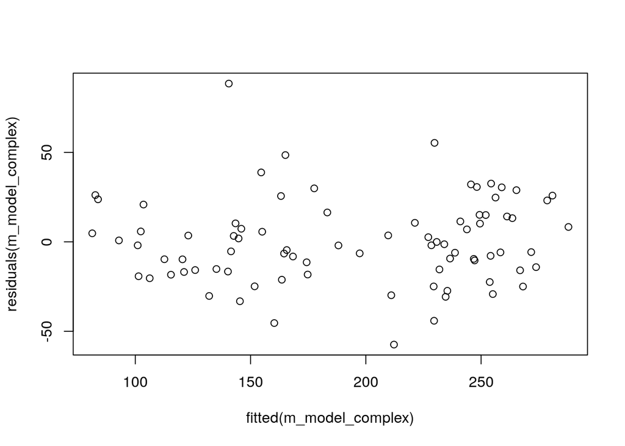

## Normality of residuals

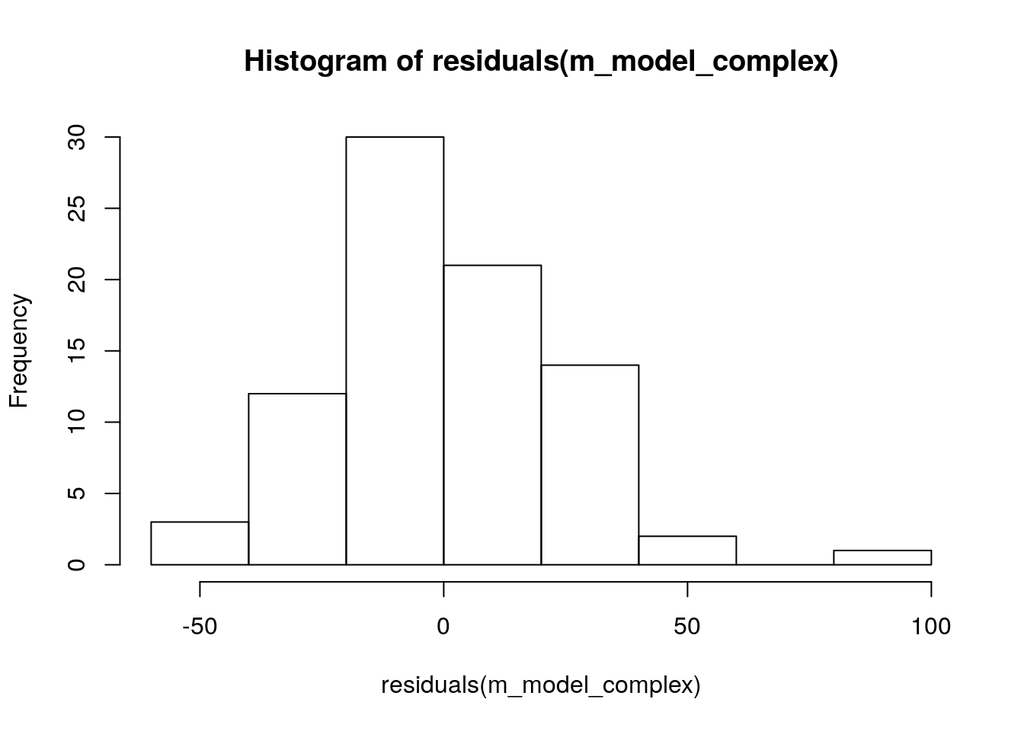

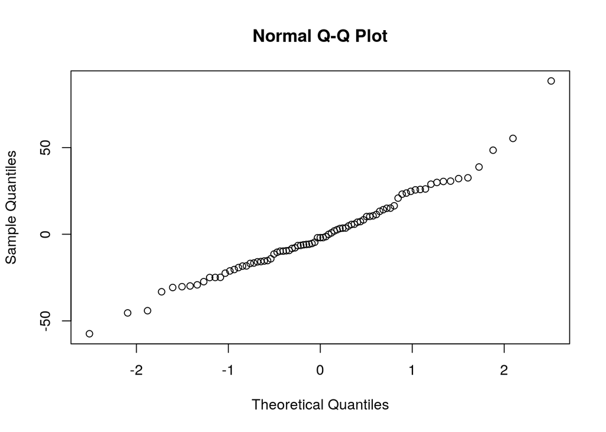

## Absence of influential data points

# Supplementary Material

## Another connection with ANOVA

One-way test

NOTE: this does not account for repeated measures from the same subject

```
##
##  One-way analysis of means (not assuming equal variances)
##
## data:  frequency and gender
## F = 178.45, num df = 1.00, denom df = 79.42, p-value < 2.2e-16
```

### ANOVA and contrasts

```
##   M
## F 0
## M 1
```

```
##
## Call:
## aov(formula = frequency ~ gender, data = df_politeness)
##
## Residuals:
##     Min      1Q  Median      3Q     Max
## -92.186 -28.426  -2.676  23.124  90.124
##
## Coefficients:
##             Estimate Std. Error t value Pr(>|t|)
## (Intercept)  246.986      5.680   43.48   <2e-16 ***
## genderM     -108.110      8.081  -13.38   <2e-16 ***
## ---
## Signif. codes:  0 '***' 0.001 '**' 0.01 '*' 0.05 '.' 0.1 ' ' 1
##
## Residual standard error: 36.81 on 81 degrees of freedom
##   (1 observation deleted due to missingness)
## Multiple R-squared:  0.6884, Adjusted R-squared:  0.6846
## F-statistic:   179 on 1 and 81 DF,  p-value: < 2.2e-16
```

### ANOVA and planned contrasts

Also see anova_basic.R

### Post-hoc tests (alternative to planned contrasts)

```
##   Tukey multiple comparisons of means
##     95% family-wise confidence level
##
## Fit: aov(formula = frequency ~ gender, data = df_politeness)
##
## $gender
##          diff       lwr       upr p adj
## M-F -108.1101 -124.1895 -92.03074     0
```

# References

[1] Winter, B. (2013). Linear models and linear mixed effects models in R with linguistic applications. arXiv:1308.5499. [http://arxiv.org/pdf/1308.5499.pdf]

[2] http://www.bodowinter.com/tutorials.html, URL accessed December 2018